# A Comparison of Variance Function Regression and Quantile Regression

Daniel Gotthardt, Christoph Naefgen & Anne Reinarz

2025-03-20

# 1 Introduction

We conducted a Monte-Carlo simulation study (Sawilowsky 2003) to evaluate and demonstrate some advantages and disadvantages of the two-step method, the maximum likelihood (ML) and restricted maximum likelihood (REML) variance function regression (VFR), and quantile regression (QR).

Western and Bloome (2009) give an extended exposition on using variance function regressions to model substantial differences in variance as indicators of differential inequality. Most approaches model the conditional expectation of the squared residuals $\epsilon_i^2$ of a conditional mean model as a function of predictors $Z_i$. In the most simple two-step model, the variance of the residuals can be expressed as the expectation of the squared residuals: $\text{Var}(\epsilon_i) = E(\epsilon_i^2) - E(\epsilon_i)^2 = E(\epsilon_i^2)$, and the conditional variance is modeled as: $\text{Var}(Y_i \mid Z_i) = E(\epsilon_i^2 \mid Z_i) = \lambda \cdot Z_i$ with ordinary least squares (OLS) regression. An improved solution takes into account that the squared residuals are non-negative and gamma-distributed if $\epsilon_i$ is normally distributed (Culpepper 2010, Appendix C), hence the use of generalized linear models (McCullagh and Nelder 1989) with a log-link $\ln(E(\epsilon_i^2 \mid Z_i))$ and gamma-distribution.

While this two-step solution takes distributional features of the residuals into account, it does ignore that the OLS residuals are biased estimators for heteroscedastic errors. To alleviate this issue, an iterative approach maximizing the likelihood of a joint expectation and variance model was proposed by Aitkin (1987). While the parameters of the joint location-scale model can be estimated with maximum likelihood (ML), the sensitivity especially of the variance parameter estimates to assumption violations (cf. Dunn and Smyth 2018, 297ff.) has led to the development of restricted maximum likelihood (REML) estimators (Verbyla 1993).

QR (Koenker and Bassett Jr 1978; Koenker 2005) is a statistical method that extends the concept of conditional boxplots to conditional quantiles dependent on categorical and continuous predictors, enabling researchers to investigate the relationships between explanatory variables and the distribution of response variables at different quantiles. Linear QR estimates the optimal linear combination of predictors $X_i$ to fit the conditional regression quantiles $Q_\tau (Y_i \mid X_i)$ for each quantile $\tau$ separately as $Q_\tau (Y_i \mid X_i) = \beta_x X_i$ by minimizing the weighted absolute deviations from this line. Comparing the regression coefficients for different quantiles facilitates a more nuanced understanding of how variability and trends differ across the distribution of the data. While QR has primarily been used to analyze inequality (cf. Killewald and Bearak 2014), it has recently been discussed as a tool to assess heterogeneous intervention effects (Marino and Farcomeni 2015; Willke et al. 2012).

This study examines how these methods perform in analyzing differences in conditional dispersion. Previous simulation studies have typically restricted their scope to a limited number of scenarios, often lacking comparisons between quantile-based and variance-based methods (Western and Bloome 2009) or have focused on medium and large sample sizes (Yang 2019). In those studies, REML and Bayesian estimation methods outperformed ML and Two-Step estimators with small sample sizes. QR was found to be robust against model misspecification (Cheng 2012; Yang 2019) and performs well in the presence of outliers (Bellio and Coletto 2016; Geraci and Bottai 2014), although this is less true for the difference between extreme quantiles (Huber and Melly 2011).

# 2 Simulation Scenarios

This Monte-Carlo experiment aims to analyze the performance of the two-step approach with gamma regression for the squared residuals, VFR with ML and REML estimation, and QR in scenarios that are often encountered by empirical researchers in the behavioral sciences. Small-sample bias is a key concern, as sample sizes in behavioral science research, including regions and individuals, are often limited. Since some experiments and larger survey-based studies include a large number of respondents, the consistency of the estimated parameters and their large-sample bias is still of interest. Complex and sometimes unknown functional forms of relationships, in addition to outliers, are also often encountered issues.

To achieve this, we defined among others the following scenarios. Given $X \sim U(1,10)$ and $Z \sim Bern(0.5)$, the true data generation processes of $Y$ are as follows.

*Scenario 1*: The variance is constant, but the expectation depends non-linearly on $X$:
$$Y_i = 0.5 + 0.5x_i + x_i^2 + 1 \epsilon_i \text{ with } \epsilon_i \sim N(0,1)$$

*Scenario 2*: The variance depends exponentially on an interaction between $X$ and $Z$:
$$Y_i = 3 + 0.5x_i + 0.2x_i^2 - z_i - 3x_i z_i + \sigma_i \epsilon_i \text{ with } \epsilon_i \sim N(0,1)$$

$$\sigma_i = \sqrt{\exp(2 + 0.5x_i + 0.2z_i - 0.4x_i z_i)}$$

*Scenario 3*: The variance depends linearly on an interaction between $X$ and $Z$:
$$Y_i = 3 + 0.5x_i + 0.2x_i^2 - z_i - 3x_i z_i + \sigma_i \epsilon_i
\text{ with } \epsilon_i \sim N(0,1)$$
$$\sigma_i = 5 + 3x_i + z_i - 2x_i$$

Each scenario was simulated 5000 times for sample sizes of 30, 50, and 1000 to study performance across small and large samples. While all methods in Scenario 1 are evaluated by Type I error rates, if the location model is misspecified, the bias, empirical standard error, and 95% confidence interval coverage rates in Scenario 2 and Scenario 3 are separately analyzed for variance-based and quantile-based methods respectively to evaluate them under a complex true data generating process without misspecification.

If an algorithm did not succeed in estimation, this estimation was excluded from the corresponding evaluation. Performance measures will then be calculated for this method without repeating the simulation. Due to the inherent statistical error of Monte-Carlo experiments, performance measures are only estimators of true performance. We calculated the Monte-Carlo standard error (MCSE) for performance measures accordingly (Morris et al., 2019, p. 2086, Table 6).

The models were estimated in R with `lm()` and `glm()` for the two-step method, with `dglm::dglm()` for the ML and REML variance function regression, and with `quantreg::rq()` for QR and `quantreg::anova.rq()` to test the difference between the QR coefficients for the second and third quartile. Performance measures and MCSE are calculated with the `rsimsum` package (Gasparini, 2018).

# 3 Results

## 3.1 Scenario 1

Focusing on the rejection rates for the null hypotheses that there is no effect of $X$ on the dispersion of $Y$, it is obvious that the two-step estimator is behaving surprisingly well but otherwise the variance function regression is identifying the quadratic location effect as a dispersion effect (Table 3.1). Furthermore, in the second stage of the Two-Step method, the gamma GLM was unable to provide any estimators for a significant percentage of the simulated datasets with small sample sizes. Therefore, the good performance measures should not be overinterpreted. With a sample size of $n = 30$, the Type I error of the REML method is 87.9% (0.5%), even higher than that of the ML method at 85.0% (0.5%). QR proves very robust even under misspecification, having only slightly higher than nominal rejection rates (6%) for $n=50$ and $n=1000$. However, it becomes clear here that misspecification of the functional term leads to significant inference problems in variance function regression, in addition to biases in the mean model.

Table 3.1: Type I Error Rates for misspecified location model

|  |  | $\beta_X$ | $\lambda_X$ |
| --- | --- | --- | --- |
| $H_0$ rejection rate, $n = 30$ |  |  |  |
|  | Two-Step | 1.000 (0.000) | 0.008 (0.001) |
|  | ML | 1.000 (0.000) | 0.850 (0.005) |
|  | REML | 1.000 (0.000) | 0.879 (0.005) |
|  | QR | 1.000 (0.000) | 0.050 (0.003) |
| $H_0$ rejection rate, $n = 50$ |  |  |  |
|  | Two-Step | 1.000 (0.000) | 0.008 (0.001) |
|  | ML | 1.000 (0.000) | 0.868 (0.005) |
|  | REML | 1.000 (0.000) | 0.888 (0.004) |
|  | QR | 1.000 (0.000) | 0.058 (0.003) |
| $H_0$ rejection rate, $n = 1000$ |  |  |  |
|  | Two-Step | 1.000 (0.000) | 0.001 (0.000) |
|  | ML | 1.000 (0.000) | 0.935 (0.003) |
|  | REML | 1.000 (0.000) | 0.935 (0.003) |
|  | QR | 1.000 (0.000) | 0.061 (0.003) |

*Note*. Based on 5000 simulation runs. $λ_X$ rejection rate for QR is estimated by F-like-test of difference of second and third quartile. Monte-Carlo standard error reported in brackets.

Figure 3.1: Histogram of estimates given a misspecified mean model

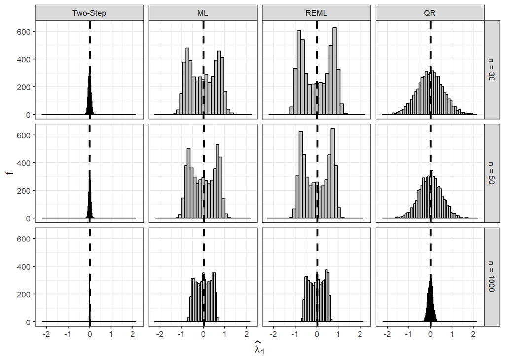

*Note*. Based on 5000 simulation runs. QR estimates are based on the difference in regression coefficients for the second and third quartiles. Extreme outliers for the two-step estimator are excluded from the plot.

## 3.2 Scenario 2 & Scenario 3

Table 3.2: Performance of VFR point estimates for exponential variance for $n = 30$ & $n = 50$

|  |  | $\lambda_0$ | $\lambda_X$ | $\lambda_Z$ | $\lambda_{XZ}$ |
| --- | --- | --- | --- | --- | --- |
| Bias of point estimates, $n = 30$ |  |  |  |  |  |
|  | Two-Step | -0.036 (0.020) | -0.045 (0.004) | 0.146 (0.028) | 0.012 (0.005) |
|  | ML | -0.666 (0.030) | 0.053 (0.005) | 0.129 (0.045) | -0.043 (0.007) |
|  | REML | -0.115 (0.021) | -0.011 (0.003) | -0.064 (0.030) | 0.009 (0.005) |
| Empirical SE of point estimates, $n = 30$ |  |  |  |  |  |
|  | Two-Step | 1.426 (0.014) | 0.286 (0.003) | 1.948 (0.020) | 0.352 (0.004) |
|  | ML | 2.135 (0.022) | 0.328 (0.003) | 3.189 (0.032) | 0.511 (0.005) |
|  | REML | 1.486 (0.015) | 0.231 (0.002) | 2.093 (0.021) | 0.362 (0.004) |
| Coverage rate of 95%-interval, $n = 30$ |  |  |  |  |  |
|  | Two-Step | 0.906 (0.004) | 0.878 (0.005) | 0.903 (0.004) | 0.896 (0.004) |
|  | ML | 0.786 (0.006) | 0.803 (0.006) | 0.777 (0.006) | 0.766 (0.006) |
|  | REML | 0.939 (0.003) | 0.937 (0.003) | 0.938 (0.003) | 0.933 (0.004) |
| Bias of point estimates, $n = 50$ |  |  |  |  |  |
|  | Two-Step | -0.034 (0.013) | -0.023 (0.003) | 0.135 (0.019) | 0.000 (0.003) |
|  | ML | -0.322 (0.013) | 0.024 (0.002) | 0.043 (0.019) | -0.017 (0.003) |
|  | REML | -0.073 (0.012) | -0.004 (0.002) | -0.039 (0.017) | 0.004 (0.003) |
| Empirical SE of point estimates, $n = 50$ |  |  |  |  |  |
|  | Two-Step | 0.906 (0.009) | 0.190 (0.002) | 1.344 (0.014) | 0.236 (0.002) |
|  | ML | 0.902 (0.009) | 0.147 (0.001) | 1.304 (0.013) | 0.216 (0.002) |
|  | REML | 0.854 (0.009) | 0.138 (0.001) | 1.230 (0.012) | 0.202 (0.002) |
| Coverage rate of 95%-interval, $n = 50$ |  |  |  |  |  |
|  | Two-Step | 0.917 (0.004) | 0.913 (0.004) | 0.919 (0.004) | 0.922 (0.004) |
|  | ML | 0.865 (0.005) | 0.884 (0.005) | 0.871 (0.005) | 0.867 (0.005) |
|  | REML | 0.940 (0.003) | 0.937 (0.003) | 0.939 (0.003) | 0.938 (0.003) |

*Note*. Based on 5000 simulation runs. Monte-Carlo standard errors reported in brackets.

Only REML estimators are close to the nominal coverage rate of 95% confidence intervals for a sample size of 50, but still have biased estimates of $λ_X$ and $λ_Z$. For a large sample of 1000 observations, all methods reach nominal coverage rates, but the two-step estimate of λ_zand the ML estimate for the intercept of the variance function $λ_0$ are still biased (Table 3.3).

Table 3.3: Performance of VFR point estimates for exponential variance for $n = 1000$

|  |  | $\lambda_0$ | $\lambda_X$ | $\lambda_Z$ | $\lambda_{XZ}$ |
| --- | --- | --- | --- | --- | --- |
| Bias of point estimates, $n = 1000$ |  |  |  |  |  |
|  | Two-Step | -0.001 (0.002) | -0.001 (0.000) | 0.013 (0.003) | -0.001 (0.000) |
|  | ML | -0.011 (0.002) | 0.000 (0.000) | 0.002 (0.003) | -0.000 (0.000) |
|  | REML | -0.002 (0.002) | -0.000 (0.000) | -0.000 (0.003) | 0.000 (0.000) |
| Empirical SE of point estimates, $n = 1000$ |  |  |  |  |  |
|  | Two-Step | 0.149 (0.001) | 0.025 (0.000) | 0.212 (0.002) | 0.035 (0.000) |
|  | ML | 0.150 (0.001) | 0.025 (0.000) | 0.212 (0.002) | 0.035 (0.000) |
|  | REML | 0.150 (0.001) | 0.025 (0.000) | 0.212 (0.002) | 0.035 (0.000) |
| Coverage rate of 95%-interval, $n = 1000$ |  |  |  |  |  |
|  | Two-Step | 0.950 (0.003) | 0.949 (0.003) | 0.949 (0.003) | 0.951 (0.003) |
|  | ML | 0.948 (0.003) | 0.949 (0.003) | 0.948 (0.003) | 0.949 (0.003) |
|  | REML | 0.950 (0.003) | 0.951 (0.003) | 0.950 (0.003) | 0.951 (0.003) |

*Note*. Based on 5000 simulation runs. Monte-Carlo standard errors reported in brackets.

Similarly, the difference of the QR coefficient estimates is biased for the small sample sizes (Table 3.4). However, the power for identifying any of the effects is also below 10% for both $n=30$ and $n=50$. Additionally, the estimates of $Δ_τ$ ($β_Z$) have a particularly high small sample bias, and have very high empirical standard errors and low rejection rates even for $n=1000$. That the empirical SE is larger than in the methods used in Scenario 2 is not particularly meaningful due to the different size of the true parameters. In both scenarios, the high uncertainty and bias for $λ_Z$ respectively the difference in $Δ_τ$ ($β_Z$) could be attributed to it being the estimate for the effect of $Z$ for $X=0$, which is outside the range of the observations. Otherwise, the difference in regression quantiles is unbiased for a sample size of 1000 and the power to identify the interaction effect on the dispersion is very high (0.988). Overall, it is evident that QR performs well only with larger datasets under the given scenario. Otherwise, the uncertainty is quite significant.

Table 3.4: Performance of difference of third and second quartile QR point estimates

|  |  | $\Delta(\beta_X)$ | $\Delta(\beta_{XX})$ | $\Delta(\beta_Z)$ | $\Delta(\beta_{XZ})$ |
| --- | --- | --- | --- | --- | --- |
| Bias of point estimates, $n = 30$ |  |  |  |  |  |
|  | QR | 0.128 (0.120) | -0.060 (0.012) | -0.916 (0.293) | 0.329 (0.060) |
| Empirical SE of point estimates, $n = 30$ |  |  |  |  |  |
|  | QR | 8.501 (0.085) | 0.815 (0.008) | 20.706 (0.207) | 4.250 (0.043) |
| $H_0$ rejection rate, $n = 30$ |  |  |  |  |  |
|  | QR | 0.056 (0.003) | 0.044 (0.003) | 0.034 (0.003) | 0.063 (0.003) |
| Bias of point estimates, $n = 50$ |  |  |  |  |  |
|  | QR | 0.130 (0.083) | -0.034 (0.008) | -0.323 (0.201) | 0.143 (0.043) |
| Empirical SE of point estimates, $n = 50$ |  |  |  |  |  |
|  | QR | 5.888 (0.059) | 0.567 (0.006) | 14.218 (0.142) | 3.060 (0.031) |
| $H_0$ rejection rate, $n = 50$ |  |  |  |  |  |
|  | QR | 0.070 (0.011) | 0.032 (0.011) | 0.026 (0.011) | 0.074 (0.011) |
| Bias of point estimates, $n = 1000$ |  |  |  |  |  |
|  | QR | -0.013 (0.017) | 0.002 (0.002) | 0.032 (0.040) | -0.009 (0.009) |
| Empirical SE of point estimates, $n = 1000$ |  |  |  |  |  |
|  | QR | 1.230 (0.012) | 0.120 (0.001) | 2.795 (0.028) | 0.641 (0.006) |
| $H_0$ rejection rate, $n = 1000$ |  |  |  |  |  |
|  | QR | 0.902 (0.003) | 0.050 (0.011) | 0.071 (0.011) | 0.988 (0.001) |

*Note*. Based on 5000 simulation runs. Monte-Carlo standard errors reported in brackets.

## 3.3 Conclusion

In conclusion, our simulation study demonstrates that none of the discussed methods are reliable for sample sizes of 30, and only REML and QR should be used for a sample size of 50. However, the power of QR is limited for this sample size in our scenarios, and more complex relationships have to be analyzed with large sample sizes or Bayesian methods that incorporate previous knowledge of researchers to allow more precise estimates in small samples (Leonard 1975; Yu and Moyeed 2001). In addition, QR proves robust not just against outliers but also against the misspecification of the location model, while the variance function regression misidentifies the unmodelled quadratic effect on the expectation as an effect on the variance.

# References

Aitkin, Murray. 1987. “Modelling Variance Heterogeneity in Normal Regression Using GLIM.” *Journal of the Royal Statistical Society: Series C (Applied Statistics)* 36 (3): 332–39. https://doi.org/10.2307/2347792.

Bellio, Ruggero, and Mauro Coletto. 2016. “Simple Outlier Labeling Based on Quantile Regression, with Application to the Steelmaking Process.” *Applied Stochastic Models in Business and Industry* 32 (2): 228–42. https://doi.org/10.1002/asmb.2146.

Cheng, Tsung-Chi. 2012. “On Simultaneously Identifying Outliers and Heteroscedasticity Without Specific Form.” *Computational Statistics & Data Analysis* 56 (7): 2258–72. https://doi.org/10.1016/j.csda.2012.01.004.

Culpepper, Steven Andrew. 2010. “Studying Individual Differences in Predictability With Gamma Regression and Nonlinear Multilevel Models.” *Multivariate Behavioral Research* 45 (1): 153–85. https://doi.org/10.1080/00273170903504885.

Dunn, Peter K., and Gordon K. Smyth. 2018. *Generalized Linear Models With Examples in R*. Springer Texts in Statistics. New York, NY: Springer New York. https://doi.org/10.1007/978-1-4419-0118-7.

Geraci, Marco, and Matteo Bottai. 2014. “Linear Quantile Mixed Models.” *Statistics and Computing* 24 (3, 3): 461–79. https://doi.org/10.1007/s11222-013-9381-9.

Huber, Martin, and Blaise Melly. 2011. “Quantile Regression in the Presence of Sample Selection.” 1109. *Economics Working Paper Series*. University of St. Gallen, School of Economics and Political Science. https://ideas.repec.org/p/usg/econwp/201109.html.

Killewald, Alexandra, and Jonathan Bearak. 2014. “Is the Motherhood Penalty Larger for Low-Wage Women? A Comment on Quantile Regression.” *American Sociological Review* 79 (2): 350–57. https://doi.org/10.1177/0003122414524574.

Koenker, Roger. 2005. *Quantile Regression*. Cambridge: Cambridge University Press. https://doi.org/10.1017/CBO9780511754098.

Koenker, Roger, and Gilbert Bassett Jr. 1978. “Regression Quantiles.” *Econometrica* 46 (1): 33–50.

Leonard, Tom. 1975. “A Bayesian Approach to the Linear Model with Unequal Variances.” *Technometrics* 17 (1): 95–102.

Marino, Maria Francesca, and Alessio Farcomeni. 2015. “Linear Quantile Regression Models for Longitudinal Experiments: An Overview.” *Metron* 73 (2): 229–47. https://doi.org/10.1007/s40300-015-0072-5.

McCullagh, Peter, and John A. Nelder. 1989. *Generalized Linear Models*. 2. Aufl. Monographs on Statistics and Applied Probability 37. London [u.a.]: Chapman & Hall.

Sawilowsky, Shlomo S. 2003. “You Think You’ve Got Trivials?” *Journal of Modern Applied Statistical Methods* 2 (1): 218–25. https://doi.org/10.22237/jmasm/1051748460.

Verbyla, Arunas Petras. 1993. “Modelling Variance Heterogeneity: Residual Maximum Likelihood and Diagnostics.” *Journal of the Royal Statistical Society: Series B (Methodological)* 55 (2): 493–508.

Western, Bruce, and Deirdre Bloome. 2009. “Variance Function Regressions for Studying Inequality.” *Sociological Methodology* 39 (1): 263–326. https://doi.org/10.1111/j.1467-9531.2009.01222.x.

Willke, Richard J., Zhiyuan Zheng, Prasun Subedi, Rikard Althin, and C. Daniel Mullins. 2012. “From Concepts, Theory, and Evidence of Heterogeneity of Treatment Effects to Methodological Approaches: A Primer.” *BMC Medical Research Methodology* 12 (1): 185. https://doi.org/10.1186/1471-2288-12-185.

Yang, Feng. 2019. “Modeling and Estimating Unpredictability with Applications in Political Economy.” Master’s thesis, Los Angeles: UCLA. https://escholarship.org/uc/item/6595x2kh.

Yu, Keming, and Rana A. Moyeed. 2001. “Bayesian Quantile Regression.” *Statistics & Probability Letters* 54 (4): 437–47.